# Dead Gene Walking Results

2024-09-26

# Introduction

This notebook explores the overlap across the results obtained in the codaton by our tool dead-gene-walking (DGW) against MicroBIGG-E.

Comparing DGW results against MicroBIGG-E:

- How many of the mutations DGW identifies are reported in MicroBIGG-E?
- How many genome accessions are present in MicroBIGG-E but do not report the mutations DGW found?

In addition:

- How prevalent are these mutations (i.e. group by lession_type and ref_gene in our output)
- What is the proportion of mutations in sensitive VS resistant?

# Setup

A total of 928 genome accession IDs for carbapenem resistant and sensitive *Pseudomonas aeruginosa* and *Klebsiella pneumoniae* were obtained from Antimicrobial susceptibility test (AST) data as follows:

*Pseudomonas aeruginosa* 359 isolates

- 292 with resistant phenotype
- 67 with sensitive phenotype

*Klebsiella pneumoniae* 569 isolates

- 297 with resistant phenotype
- 272 with sensitive phenotype

The accession numbers for these genomes are found in the project repository [here](https://github.com/NCBI-Codeathons/amr-2024-team-prasad-feldgarden/tree/main/data/dev-examples/resis_and_sens_Kp_and_Pa).

## MicroBIGG-E subset

A subset of the data available in MicroBIGG-E for the selected isolates was obtained from BigQuery and stored in the repository [here](https://github.com/NCBI-Codeathons/amr-2024-team-prasad-feldgarden/blob/main/results/microbigge_subset.csv).

## DGW results

DGW was ran as described [here](https://github.com/NCBI-Codeathons/amr-2024-team-prasad-feldgarden/tree/main/script), and the output for each taxon is shown in individual tables in the repository [here](https://github.com/NCBI-Codeathons/amr-2024-team-prasad-feldgarden/tree/main/results). These results are going to be compared against the MicroBIGG-E subset in the following section.

# Analysis of results

```r
# Install packges
library(DBI)
library(duckdb)
library(tidyverse)
library(dplyr)


# Import data
Kp_resistant <- read_tsv("results/Kpresis.dgw")
Pa_resistant <- read_tsv("results/Paresis.dgw")
Kp_sensitive <- read_tsv("results/Kpsens.dgw")
Pa_sensitive <- read_tsv("results/Pasens.dgw")
microbigge <-  read_csv("results/microbigge_subset.csv")

# Set up in-memory database for modeling
con <- dbConnect(duckdb(), dbdir = ":memory:")

# Register dfs into database
dbWriteTable(con, "kp_resistant", Kp_resistant)
dbWriteTable(con, "pa_resistant", Pa_resistant)
dbWriteTable(con, "kp_sensitive", Kp_sensitive)
dbWriteTable(con, "pa_sensitive", Pa_sensitive)
dbWriteTable(con, "microbigge", microbigge)
```

Let’s first prepare the data to establish the comparisons/analysis.

```r
# Combine DGW results
dgw_combined <- dbGetQuery(con,
"SELECT
  *,
  md5(CONCAT(element_symbol, asm_acc, contig_acc, lesion)) AS mutation_id,
  'kp_resistant' AS cohort
FROM kp_resistant
UNION ALL
SELECT
  *,
  md5(CONCAT(element_symbol, asm_acc, contig_acc, lesion)) AS mutation_id,
  'pa_resistant' AS cohort
FROM pa_resistant
UNION ALL
SELECT
  *,
  md5(CONCAT(element_symbol, asm_acc, contig_acc, lesion)) AS mutation_id,
  'kp_sensitive' AS cohort
FROM kp_sensitive
UNION ALL
SELECT
  *,
  md5(CONCAT(element_symbol, asm_acc, contig_acc, lesion)) AS mutation_id,
  'pa_sensitive' AS cohort
FROM pa_sensitive
")
dbWriteTable(con, "dgw_combined", dgw_combined, overwrite = TRUE)


# Is DGW reported in MicroBIGG-E?
dgw_in_mbigge <- dbGetQuery(con,
"SELECT
  dgw_combined.element_symbol,
  dgw_combined.asm_acc,
  dgw_combined.contig_acc,
  dgw_combined.lesion,
  dgw_combined.lesion_type,
  dgw_combined.cohort,
  dgw_combined.mutation_id,
  microbigge.element_symbol AS mb_element_symbol,
  microbigge.class
FROM dgw_combined
LEFT JOIN microbigge
ON dgw_combined.asm_acc = microbigge.asm_acc
AND LOWER(microbigge.element_symbol) LIKE CONCAT('%', LOWER(dgw_combined.element_symbol),'%')
WHERE cohort LIKE '%resistant'
")

sensitive_and_resistant_acc <- dgw_combined %>%
  group_by(asm_acc, contig_acc) %>%
  filter(n_distinct(cohort) >1) %>%
  select(asm_acc, contig_acc)

#Find new mutations against MicroBIGG-E mutations
dgw_new <- dbGetQuery(con,
"WITH match AS (
SELECT DISTINCT
  mutation_id
FROM dgw_combined
WHERE LOWER(microbigge.element_symbol) LIKE CONCAT('%', LOWER(dgw_combined.element_symbol),'%')
)
SELECT DISTINCT
  dgw_combined.element_symbol,
  dgw_combined.asm_acc,
  dgw_combined.contig_acc,
  dgw_combined.lesion,
  dgw_combined.lesion_type,
  dgw_combined.cohort,
  STRING_AGG(microbigge.element_symbol) OVER (PARTITION BY dgw_combined.element_symbol, dgw_combined.asm_acc) AS mb_element_symbol,
FROM dgw_combined
LEFT JOIN microbigge
ON dgw_combined.asm_acc = microbigge.asm_acc
LEFT JOIN match
USING(mutation_id)
WHERE dgw_combined.cohort LIKE '%resistant'
AND match.mutation_id IS NULL
")
```

*NOTE: Some contigs are marked as both sensitive and resistant, stored in `sensitive_and_resistant_acc` df.*

## How many of the mutations DGW identifies are reported in MicroBIGG-E?

Out of the 928 isolates analyzed by DGW, 522 unique mutations were found across 458 isolates. - 130 mutations were also present in MicroBIGG-E

```r
#Total output
dgw_output_combined <- dgw_combined %>%
  summarize(mutations = n_distinct(mutation_id, na.rm = TRUE),
            isolates = n_distinct(asm_acc, na.rm = TRUE),
            contigs = n_distinct(contig_acc, na.rm = TRUE))


# question1
q1 <- dgw_in_mbigge %>%
  filter(!is.na(mb_element_symbol)) %>%
  group_by(element_symbol) %>%
  summarize(mutations = n_distinct(mutation_id),
            isolates = n_distinct(asm_acc)) %>%
  arrange(desc(mutations))

# q1_inverse <- dgw_in_mbigge %>%
#   filter(is.na(mb_element_symbol)) %>%
#   group_by(element_symbol) %>%
#   summarize(mutations = n_distinct(mutation_id),
#             isolates = n_distinct(asm_acc))


print(q1)
```

```
## # A tibble: 3 × 3
##   element_symbol mutations isolates
##   <chr>              <int>    <int>
## 1 OprD                 121      121
## 2 OmpK36                 5        5
## 3 OmpK35                 4        4
```

## How many isolates are present in MicroBIGG-E but do not report the mutations DGW found?

Out of the 493 mutations found in resistant isolates present in MicroBIGG-E, DGW found 363 new mutations in 353 isolates.

```r
# q2
q2 <- dgw_in_mbigge %>%
  filter(is.na(mb_element_symbol)) %>%
  mutate(phenotype = case_when(grepl("resistant", cohort) ~ "Resistant",
                               grepl("sensitive", cohort) ~ "Sensitive"),
         taxon = case_when(grepl("kp", cohort) ~ "Klebsiella pneumoniae",
                           grepl("pa", cohort) ~ "Pseudomonas aeruginosa")) %>%
  group_by(phenotype, taxon, element_symbol, lesion, lesion_type) %>%
  summarize(mutations = n_distinct(mutation_id),
            isolates = n_distinct(asm_acc)) %>%
  arrange(desc(mutations))

print(q2)
```

```
## # A tibble: 97 × 7
## # Groups:   phenotype, taxon, element_symbol, lesion [97]
##    phenotype taxon          element_symbol lesion lesion_type mutations isolates
##    <chr>     <chr>          <chr>          <chr>  <chr>           <int>    <int>
##  1 Resistant Pseudomonas a… OprD           D286fs FRAMESHIFT         81       81
##  2 Resistant Klebsiella pn… OmpK35         G41fs  FRAMESHIFT         65       65
##  3 Resistant Pseudomonas a… AmpD           W97ST… STOP               50       50
##  4 Resistant Pseudomonas a… OprD           E181fs FRAMESHIFT         24       24
##  5 Resistant Klebsiella pn… OmpK35         K95fs  FRAMESHIFT         13       13
##  6 Resistant Klebsiella pn… OmpK35         S301fs FRAMESHIFT          6        6
##  7 Resistant Klebsiella pn… OmpK35         D108fs FRAMESHIFT          5        5
##  8 Resistant Klebsiella pn… OmpK36         K62ST… STOP                5        5
##  9 Resistant Klebsiella pn… OmpK35         F166fs FRAMESHIFT          4        4
## 10 Resistant Klebsiella pn… OmpK35         L63fs  FRAMESHIFT          4        4
## # ℹ 87 more rows
```

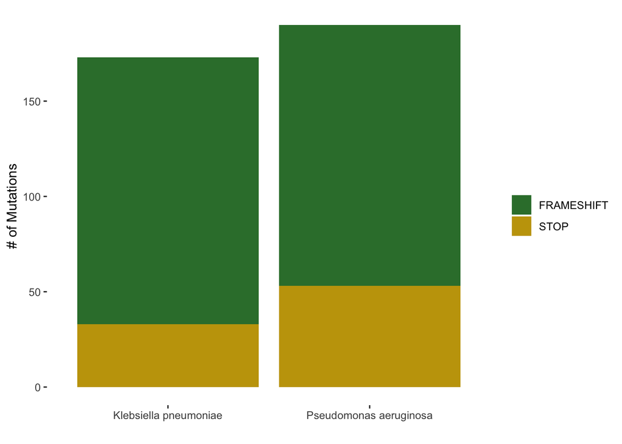

```r
# proportion of new mutations
q2 %>%
  group_by(lesion_type, taxon) %>%
  summarize(mutations = sum(mutations)) %>%
  ggplot(., aes(fill=lesion_type, y=mutations, x=taxon)) +
    geom_bar(position="stack", stat="identity") +
    scale_fill_manual(name="",values=c('#347d38', '#c4a208')) +
    theme(
      panel.grid.major = element_blank(),
      panel.grid.minor = element_blank(),
      panel.border = element_blank(),
      panel.background = element_blank()) +
    ylab("# of Mutations") + xlab("")
```

```r
# New mutations
print(dgw_new %>% filter(contig_acc == "CP021955.1"))
```

```
##   element_symbol         asm_acc contig_acc lesion lesion_type       cohort
## 1         OmpK35 GCA_002202275.1 CP021955.1 S110fs  FRAMESHIFT kp_resistant
## 2         OmpK36 GCA_002202275.1 CP021955.1  Q54fs  FRAMESHIFT kp_resistant
##                                                                                                                                                                                                                                                                                                mb_element…
## 1 qacEdelta1,pcoS,qacEdelta1,arsD,arsC,arsC,blaOXA-9,cmlA5,gyrA_S83L,arsA,aadA1,sul1,qacEdelta1,aadA1,aadA1,emrD,silC,blaOXA-10,pcoD,blaOXA-10,pcoA,pcoB,silR,silB,silS,silA,fieF,aac(6')-Ib,parC_S80I,arsB,rmtG,arsR,gyrA_D87Y,fosA,asr,silE,blaCTX-M-2,pcoC,pcoR,arr-2,blaTEM-1,silP,sul2,silF,blaSHV-1…
## 2 sul1,gyrA_S83L,arsA,cmlA5,blaSHV-187,qacEdelta1,silE,blaTEM-1,pcoB,silS,parC_S80I,emrD,silA,arsR,sul1,blaOXA-10,aadA1,fosA,aadA1,aac(6')-Ib,arr-2,silR,blaOXA-9,pcoD,aadA1,silC,sul2,blaOXA-10,pcoA,qacEdelta1,pcoS,asr,arsB,pcoR,fieF,arsD,pcoC,arsC,silB,gyrA_D87Y,arsC,blaCTX-M-2,silP,qacEdelta1,rm…
```

## How prevalent are these mutations (i.e. group by lession_type and ref_gene in our output) and what is the proportion of mutations in sensitive VS resistant?

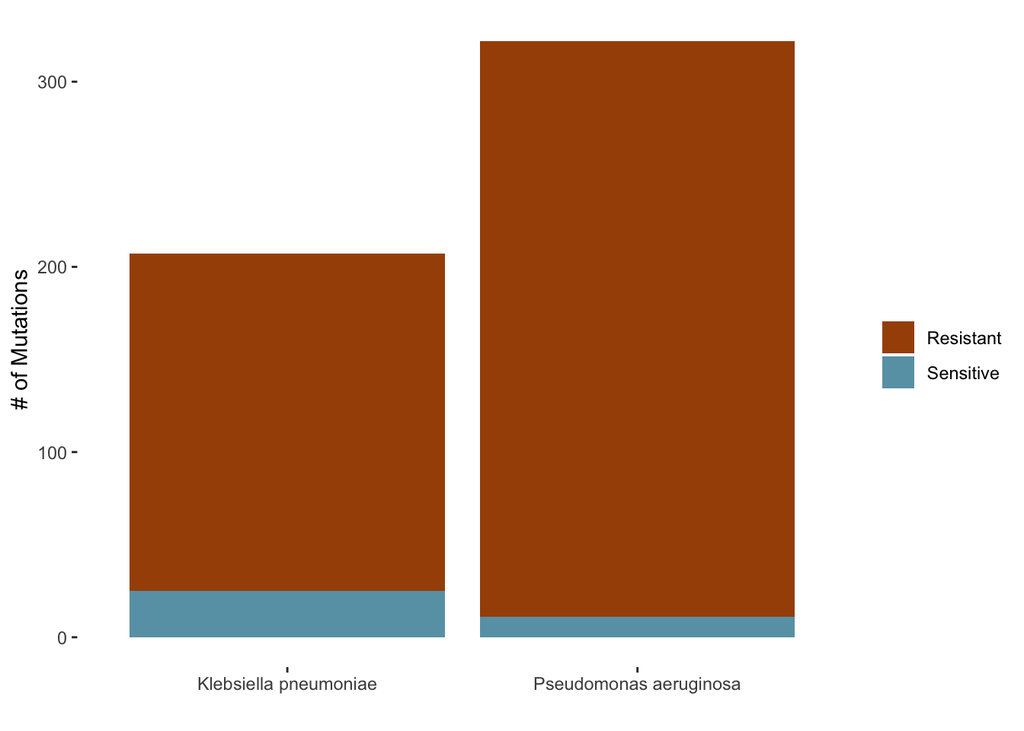

```r
# q3
q3 <- dgw_combined %>%
  mutate(phenotype = case_when(grepl("resistant", cohort) ~ "Resistant",
                               grepl("sensitive", cohort) ~ "Sensitive"),
         taxon = case_when(grepl("kp", cohort) ~ "Klebsiella pneumoniae",
                           grepl("pa", cohort) ~ "Pseudomonas aeruginosa")) %>%
  group_by(phenotype, taxon, lesion) %>%
  summarize(mutations = n_distinct(mutation_id),
            isolates = n_distinct(asm_acc))


dgw_combined %>%
  mutate(phenotype = case_when(grepl("resistant", cohort) ~ "Resistant",
                               grepl("sensitive", cohort) ~ "Sensitive"),
         taxon = case_when(grepl("kp", cohort) ~ "Klebsiella pneumoniae",
                           grepl("pa", cohort) ~ "Pseudomonas aeruginosa")) %>%
  group_by(phenotype, taxon) %>%
  summarize(mutations = n_distinct(mutation_id),
            isolates = n_distinct(asm_acc)) %>%
  ggplot(., aes(fill=phenotype, y=mutations, x=taxon)) +
    geom_bar(position="stack", stat="identity") +
    scale_fill_manual(name="",values=c('#a65005', '#68a1b3')) +
    theme(
      panel.grid.major = element_blank(),
      panel.grid.minor = element_blank(),
      panel.border = element_blank(),
      panel.background = element_blank()) +
    ylab("# of Mutations") + xlab("")
```

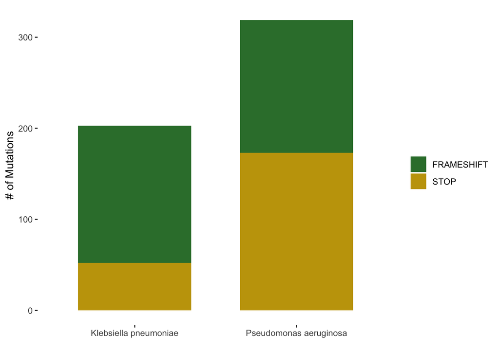

```r
# q3.2
q3_2 <- dgw_combined %>%
  group_by(lesion_type) %>%
  summarize(mutations = n_distinct(mutation_id),
            isolates = n_distinct(asm_acc))

dgw_combined %>%
  mutate(taxon = case_when(grepl("kp", cohort) ~ "Klebsiella pneumoniae",
                           grepl("pa", cohort) ~ "Pseudomonas aeruginosa")) %>%
  group_by(lesion_type, taxon) %>%
  summarize(mutations = n_distinct(mutation_id),
            isolates = n_distinct(asm_acc)) %>%
  ggplot(., aes(fill=lesion_type, y=mutations, x=taxon)) +
    geom_bar(position="stack", stat="identity", width=0.7) +
    scale_fill_manual(name="",values=c('#347d38', '#c4a208')) +
    theme(
      panel.grid.major = element_blank(),
      panel.grid.minor = element_blank(),
      panel.border = element_blank(),
      panel.background = element_blank()) +
    ylab("# of Mutations") + xlab("")
```

# Summary

- 928 isolates were analyzed by DGW
  - 359 *Pseudomonas aeruginosa* isolates
    - 292 with resistant phenotype
    - 67 with sensitive phenotype
  - 569 *Klebsiella pneumoniae* isolates
    - 297 with resistant phenotype
    - 272 with sensitive phenotype
- Of the 589 resistant isolates
  - 493 mutations
    - 130 mutations were present in MicroBIGG-E too
    - 363 new mutations in 353 isolates

  Additionally, DGW found frameshift mutations in OmpK35 and OmpK36 in CP021955.1/SAMN04014948, which does not appear to have any carbapenemases and is still highly resistant to carbapenems (and other beta-lactams).

```r
dgw_new %>% filter(contig_acc == 'CP021955.1')
```

```
##   element_symbol         asm_acc contig_acc lesion lesion_type       cohort
## 1         OmpK35 GCA_002202275.1 CP021955.1 S110fs  FRAMESHIFT kp_resistant
## 2         OmpK36 GCA_002202275.1 CP021955.1  Q54fs  FRAMESHIFT kp_resistant
##                                                                                                                                                                                                                                                                                                mb_element…
## 1 qacEdelta1,pcoS,qacEdelta1,arsD,arsC,arsC,blaOXA-9,cmlA5,gyrA_S83L,arsA,aadA1,sul1,qacEdelta1,aadA1,aadA1,emrD,silC,blaOXA-10,pcoD,blaOXA-10,pcoA,pcoB,silR,silB,silS,silA,fieF,aac(6')-Ib,parC_S80I,arsB,rmtG,arsR,gyrA_D87Y,fosA,asr,silE,blaCTX-M-2,pcoC,pcoR,arr-2,blaTEM-1,silP,sul2,silF,blaSHV-1…
## 2 sul1,gyrA_S83L,arsA,cmlA5,blaSHV-187,qacEdelta1,silE,blaTEM-1,pcoB,silS,parC_S80I,emrD,silA,arsR,sul1,blaOXA-10,aadA1,fosA,aadA1,aac(6')-Ib,arr-2,silR,blaOXA-9,pcoD,aadA1,silC,sul2,blaOXA-10,pcoA,qacEdelta1,pcoS,asr,arsB,pcoR,fieF,arsD,pcoC,arsC,silB,gyrA_D87Y,arsC,blaCTX-M-2,silP,qacEdelta1,rm…
```

```r
# Frequency of OmpKs in sensitive isolates
dgw_combined %>%
  group_by(cohort, element_symbol) %>%
  summarize(mutants = n_distinct(mutation_id)) %>%
  filter(element_symbol %in% c('OmpK35', 'OmpK36'))
```

```
## # A tibble: 4 × 3
## # Groups:   cohort [2]
##   cohort       element_symbol mutants
##   <chr>        <chr>            <int>
## 1 kp_resistant OmpK35             143
## 2 kp_resistant OmpK36              38
## 3 kp_sensitive OmpK35              15
## 4 kp_sensitive OmpK36               4
```